# Mini Projeto 02

Aprendizado Não-Supervisionado - Professor Mateus Mendelson

Integrantes: Nasser Santiago Boan, Emmanuel Moreira, Harlan Martins

O objetivo desse projeto é implementar um algoritmo PAM (Partitioning Around Medoids). O PAM é um algoritmo de clusterização de aprendizado não supervisionado, utilizado para procurar subsets dentro um conjunto de dados que se assemelham em termos de suas características X. Seu método de escolha dos medoids o torna menos sensível a outliers que seu semelhante k-means.

## Preparando os dados

Para que os dados estejam prontos para ser usados devemos, inicialmente, executar o script 'make_dataset.py'. Conforme abaixo.

```python
!python src/make_dataset.py
```

```
>> Lendo e tratando dataset!
>> Dataset criado em 'data/meu_dataset.csv'
>> O Dataset possui 1570 linhas e 3 colunas.
```

Com o dataset carregado e criado, podemos agora começar a implementação do algoritmo. O algoritmo será implementado com o nome de classe MyPAM.

```python
import pandas as pd
import plotly.express as px
import plotly.graph_objects as go
import numpy as np
import math
import numpy as np
from scipy.spatial import distance

#alpha: indica a quantidade de tentativas sem melhoria de custo total médio que
#devem ser realizadas antes da interrupção do algoritmo
class MyPAM:
    def __init__(self, k=3, max_iter=300, alpha=50, data=None):
        self.k = k
        self.max_iter = max_iter
        self.alpha = alpha
        self.data = data
        self.medoids = []
        self.ex_medoids = []
        self.curr_error = np.inf


    def _random_medoid(self):
        """sorteia um ponto dentro do dataset.
        o ponto nao pertence ao atual conjunto de medoids nem ao conjunto de ex medoids"""
        point = self.data[np.random.randint((len(self.data)))]
        # nao podemos repetir medoids

        while ((any([list(point) == list(p) for p in self.medoids])) |
               (any([list(point) == list(p) for p in self.ex_medoids]))):

            point = self.data[np.random.randint((len(self.data)))]

        return point

    def _initialize_medoids(self):
        """gera os primeiros k medoids escolhendo k indices diferentes em data"""

        initial_medoids = []
        aux_index = []

        # garantir k indices diferentes
        while (len(set(aux_index)) < self.k):
            aux_index = []
            for i in range(self.k):
                aux_index.append(np.random.randint((len(self.data))))

        for i in aux_index:
            initial_medoids.append([self.data[i,0], self.data[i,1]])

        return np.array(initial_medoids)


    def _medoid_to_substitute(self, new_medoid):
        """retorna o indice do medoid a ser substituido (aquele com a menor
        distancia euclidiana do novo medoid)"""
        aux_index = 0
        d = np.inf
        for i in range(len(self.medoids)):
            if (distance.euclidean(self.medoids[i], new_medoid) < d):
                d = distance.euclidean(self.medoids[i], new_medoid)
                aux_index = i
        return aux_index

    # classification: dicionario contendo os conjuntos de pontos para cada cluster
    def myMSE(self, classification):
        s = []
        for i in classification:
            d = [
                    (self.medoids[i][0] - p[0])**2 +
                    (self.medoids[i][1] - p[1])**2
                    for p in classification[i]
                ]
            s.append(sum(d)/(1+len(classification[i])))


        return sum(s)


    def fit_pam(self,verbose=0):

        self.medoids = self._initialize_medoids()

        self.ex_medoids = np.array([[0,0]])

        stop = self.medoids.copy()


        ## iterando sobre a quantidade max_iter e tentativa_sem_melhora (seguidas)

        iteracao = 0
        tentativa_sem_melhora = 0
        while (iteracao < self.max_iter) & (tentativa_sem_melhora < self.alpha):


            ## criando os clusters
            classification = {}
            for cluster in range(self.k): #k = 3
                classification[cluster] = []
            ## calculando as distancias
            for point in self.data: #df[['cases','deaths']].values
                distancias = [math.sqrt((medoid[0] - point[0])**2 +
                                        (medoid[1] - point[1])**2)
                              for medoid in self.medoids]
                ## achando o indice do menor valor na lista distancias
                cluster = np.argmin(distancias)
                ## adicionando esse ponto ao cluster
                classification[cluster].append([value for value in point])


            # novo medoid aleatorio
            new_medoid = self._random_medoid()
            # indice do medoid atual a ser substituido pelo novo
            index = self._medoid_to_substitute(new_medoid)
            # manter historico de ex medoids (para nao serem repetidos)
            self.ex_medoids = np.append(self.ex_medoids, [self.medoids[index]], axis=0)
            # manter estado atual dos medoids, caso nao haja melhora, sera mantido
            curr_medoids = self.medoids.copy()
            # colocar o medoid novo no conjunto de medoids
            self.medoids[index] = new_medoid

            #if verbose == 1:
            #    print(f'new med: {new_medoid} substitui index: {index}')
            #    print(f'ex medoids:\n {self.ex_medoids}')
            #    print('xxx')
            #    print(f'medoids:\n {self.medoids}')
            #    for i in range(len(classification)):
            #        print(f'tamanho do cluster: {i}:{len(classification[i])}')

            # verificar erro dessa iteração

            erro_atual = self.myMSE(classification)

            #if verbose == 1 :
            #    print(f'Iteração: {iteracao}')
            #    print(f'Tentativas sem melhoria: {tentativa_sem_melhora}')
            #    print(f'MSE: {erro_atual:.4e}')
            #    print(f'curr error: {self.curr_error:.4e}')

            # houve melhora?

            if (erro_atual >= self.curr_error):
                tentativa_sem_melhora += 1
                # manter conjunto de medoids anterior
                self.medoids = curr_medoids
            else:
                tentativa_sem_melhora = 0
                self.curr_error = erro_atual

            ## contando iterações
            iteracao+=1

            stop = self.medoids.copy()

        # fim while

        if verbose == 1 :
            print(f'Iterações: {iteracao}\ntentativas seguidas sem melhora: {tentativa_sem_melhora}')
            print(f'Últimos medoids: \n{self.medoids}')

        self.stop = stop
        self.classification = classification


    def show_plot(self):

        if self.k <= 10:

            data_framed = []

            for cluster in self.classification:
                for point in self.classification[cluster]:
                    point.append(cluster)
                    data_framed.append(point)

            df_plot = pd.DataFrame(data_framed,columns=['cases','deaths','cluster'])
            df_plot['cluster'] = df_plot['cluster'].astype('str')

            fig = px.scatter(df_plot, x = 'cases', y = 'deaths',
                             color = 'cluster',
                             color_discrete_sequence=px.colors.qualitative.Plotly[:self.k],
                             title='Data and Medoids')
            fig.add_scatter(x = self.stop[:,0],
                            y = self.stop[:,1],mode='markers',
                            name='Medoid',marker=dict(size=[20 for _ in range(self.k)],
                            symbol='x',color=px.colors.qualitative.Plotly[:self.k]))

            fig.show()

        else:
            raise ValueError('plot can only be constructed with 10 or less clusters.')

    def labels_(self):

        labels = []

        for cluster in range(self.k):
            for i in range(len(self.classification[cluster])):
                labels.append(cluster)

        return labels

    def distances_(self,method):

        if method == 'mean':
            """ O desafio pede a média de todas as distâncias a seus referentes clusters """
            dist = {}

            for cluster in self.classification:
                dist[cluster] = np.mean([math.sqrt((self.stop[cluster][0] - point[0])**2 + (self.stop[cluster][1] - point[1])**2) for point in self.classification[cluster]])

            return dist

        elif method == 'inertia':
            """ Já inertia pede a soma """

            dist = {}

            for cluster in self.classification:
                dist[cluster] = np.sum([((self.stop[cluster][0] - point[0])**2 + (self.stop[cluster][1] - point[1])**2) for point in self.classification[cluster]])

            inertia = sum(dist.values())

            return inertia

    def try_k(self,how_many=10):

        data = []

        self.original_k = self.k

        for k in range(2,how_many):
            self.k = k
            self.fit_pam()
            data.append(self.distances_('inertia'))


        fig = go.Figure(data=go.Scatter(x = list(range(2,how_many)),
                                        y = data,
                                        marker_line_color="midnightblue",
                                        marker_color="lightskyblue",
                                        marker_line_width=2, marker_size=7))
        fig.update_layout(title='Finding the Elbow Point')
        fig.show()
```

Com o algortimo implementado acima podemos ler o dataset tratado e começar os testes.

```python
## carregando o dataset tratado

df = pd.read_csv('data/meu_dataset.csv')
print(df.shape)
df.head()
```

```
(1570, 3)
```

|  | county | cases | deaths |
| --- | --- | --- | --- |
| 0 | Abbeville | 84 | 0 |
| 1 | Acadia | 741 | 21 |
| 2 | Accomack | 116 | 0 |
| 3 | Ada | 4264 | 41 |
| 4 | Adair | 325 | 8 |

Primeiramente vamos instanciar o algoritmo MyPAM e guardar dentro da variável 'sol'. A construção da classe pede alguns parâmetros:

- k --> A quantidade de clusters que iremos utilizar no algoritmo;
- max_iter --> O número máximo de iterações que o algoritmo irá executar;
- alpha --> Valor que indica a quantidade de tentativas seguidas sem melhoria de custo total médio que devem ser realizadas antes da interrupção do algoritmo;
- data --> Dados para treinamento.

```python
## instanciando o algoritmo

sol = MyPAM(k=5,data = df[['cases','deaths']].values,max_iter = 300, alpha=50)
```

Primeiramente vamos testar vários valores de K para descobrirmos o valor ótimo através do método Elbow. Nesse caso testaremos nosso modelos num range de 2 até 10.

```python
sol.try_k(11)
```

[interactive chart not shown]

No eixo Y temos a inércia de cada iteração do algoritmo. Percebemos que a inércia fica na faixa de 900B-950B na maioria das execuções. Como o PAM é baseado totalmente na aleatoriedade, ele não apresenta uma convergência com valores baixos (até 10 clusters). Essa característica também tem a consequência de colocar os medoids em áreas mais densas, dada a maior chance de um ponto ser sorteado naquela área (sendo assim, seu desempenho depende da densidade dos clusters existentes no dataset).

Como podemos ver nos gráficos abaixo, nosso dataset possui uma concentração muito grande.

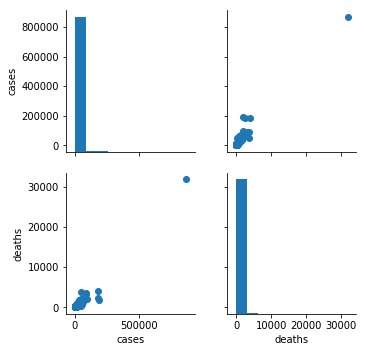

```python
import seaborn as sns
import matplotlib.pyplot as plt
g = sns.PairGrid(df[['cases','deaths']])
g.map_diag(plt.hist)
g.map_offdiag(plt.scatter)
plt.show()
```

Escolhemos arbitrariamente o k = 4

```python
## reinstanciando o modelo com novo valor de K

sol = MyPAM(k=4,data = df[['cases','deaths']].values,max_iter = 300)
```

Agora estamos prontos para treinar o modelo.

```python
## treinando o modelo

sol.fit_pam(verbose=1)
```

```
Iterações: 52
tentativas seguidas sem melhora: 50
Últimos medoids:
[[  121     4]
 [54023  1704]
 [ 2852   104]
 [   78     1]]
```

Ao treinar o algoritmo ele diz quantas iterações foram necessárias para convergir levando em consideração o número máximo de iterações e a quantidade máxima de iterações sem melhoria. Podemos, então verificar os pontos e seus medoids.

```python
sol.show_plot()
```

[interactive chart not shown]

Cada cluster acima com seu medoid associado representam pontos, ou nesse caso cidades, que possuem um comportamento de casos e mortes de covid-19 semelhantes. Podemos analisar as médias das distâncias dos pontos de cada cluster a seu medoid.

```python
## demonstrando as distâncias

sol.distances_('mean')
```

```
{0: 317.1317786902885,
 1: 65285.11322459591,
 2: 3454.3432818076967,
 3: 44.84478438265507}
```

Novamente, a aleatoriedade do algorítmo e a distribuição do dataset analisado formam clusters com distâncias bastante distintas. Na maioria das vezes, os medoids ficarão concentrados perto da área de maior densidade, onde os casos e as mortes são baixos. Assim, um dos clusters sempre vai possuir uma distância bem superior aos outros, aquele que tiver os outliers como seus pontos.

#### Comparação da inércia do PAM com o K-Means do Sklearn

A inércio do PAM sempre foi maior que do K-Means em todos os testes

```python
## inércia do MyPAM

print(f"{sol.distances_('inertia'):.4e}")
```

```
7.3177e+11
```

```python
## inércia do sklearn.cluster.KMeans

from sklearn.cluster import KMeans
kmeans_i=KMeans(n_clusters=4,max_iter=300,tol=0.0001).fit(df[['cases','deaths']].values).inertia_
print(f"{kmeans_i:.4e}")
```

```
1.9332e+10
```

#### Comparação de tempo com o K-Means do Sklearn

O K-Means executa muito mais rápido que o nosso PAM

```python
%%timeit
KMeans(n_clusters=4,max_iter=300,tol=0.0001).fit(df[['cases','deaths']].values)
```

```
14.2 ms ± 107 µs per loop (mean ± std. dev. of 7 runs, 100 loops each)
```

```python
%%timeit
sol = MyPAM(k=4,max_iter=300,data=df[['cases','deaths']].values)
sol.fit_pam()
```

```
1.4 s ± 454 ms per loop (mean ± std. dev. of 7 runs, 1 loop each)
```